# Cancer Deaths in Hiroshima and Nagasaki Survivors

Winter 2020

```r
library(tidyverse)
library(dplyr)
library(ggplot2)
```

## Opening file with Fortran format and cleaning up column names

```r
fstr <- c("2I3","I4","F7.1","I5","I4","F10.2","26I4")
hiroshima_nagasaki <- read.fortran("r10cancrfix.dat",fstr)

names(hiroshima_nagasaki) <-  c("city", "sex", "ageatb", "dose_centigray", "time", "index", "total_year", "alldeaths", "alldis", "allneo", "allmal", "leuk", "nonleuk", "digest", "esoph", "stomach", "colon", "rectum", "liver", "gallbldr", "pancreas", "othrdig", "resp", "lung", "fbreast", "fgenital", "cervix", "ovary", "prostate", "urinary", "lymphoma", "myeloma", "othrca")

hiroshima_nagasaki <- hiroshima_nagasaki %>%
  mutate_at(vars(city), ~str_replace_all(., "0", "Hiroshima")) %>%
  mutate_at(vars(city), ~str_replace_all(., "1", "Nagasaki")) %>%
  mutate_at(vars(sex), ~str_replace_all(., "0", "M")) %>%
  mutate_at(vars(sex), ~str_replace_all(., "1", "F")) %>%
  mutate_at(vars(time), ~paste0("19", .)) %>%
  rowid_to_column(var='observation') %>%
  mutate_at(vars(dose_centigray), as.factor) %>%
  mutate_at(vars(ageatb), as.factor)


hiroshima_nagasaki
```

```
##      observation      city sex ageatb dose_centigray time index total_year
## 1              1 Hiroshima   M      5              0 1952     1   109.7898
## 2              2 Hiroshima   M      5              0 1956     2   102.8735
## 3              3 Hiroshima   M      5              0 1960     3   102.2300
## 4              4 Hiroshima   M      5              0 1964     4   101.6771
## 5              5 Hiroshima   M      5              0 1968     5   101.1862
## 6              6 Hiroshima   M      5              0 1972     6   100.6086
## 7              7 Hiroshima   M      5              0 1976     7    99.9539
## 8              8 Hiroshima   M      5              0 1980     8    99.2397
## 9              9 Hiroshima   M      5           0.33 1952     1    61.4030
## 10            10 Hiroshima   M      5           0.33 1956     2    57.4994
## 11            11 Hiroshima   M      5           0.33 1960     3    57.1393
## 12            12 Hiroshima   M      5           0.33 1964     4    56.8748
## 13            13 Hiroshima   M      5           0.33 1968     5    56.5317
## 14            14 Hiroshima   M      5           0.33 1972     6    55.9826
```

[output cut: 5109 more lines]

## How many NA’s?

```r
naniar::miss_var_summary(hiroshima_nagasaki)
```

```
## # A tibble: 34 x 3
##    variable       n_miss pct_miss
##    <chr>           <int>    <dbl>
##  1 observation         0        0
##  2 city                0        0
##  3 sex                 0        0
##  4 ageatb              0        0
##  5 dose_centigray      0        0
##  6 time                0        0
##  7 index               0        0
##  8 total_year          0        0
##  9 alldeaths           0        0
## 10 alldis              0        0
## # … with 24 more rows
```

## Tidying Data

```r
tidy_hiroshima_nagasaki <- hiroshima_nagasaki %>%
  pivot_longer(-c(observation, city, sex, ageatb, dose_centigray, time, index, total_year, alldeaths),
               names_to = "type_death",
               values_to = "number_death")

tidy_hiroshima_nagasaki
```

```
## # A tibble: 32,000 x 11
##    observation city  sex   ageatb dose_centigray time  index total_year
##          <int> <chr> <chr> <fct>  <fct>          <chr> <int>      <dbl>
##  1           1 Hiro… M     5      0              1952      1       110.
##  2           1 Hiro… M     5      0              1952      1       110.
##  3           1 Hiro… M     5      0              1952      1       110.
##  4           1 Hiro… M     5      0              1952      1       110.
##  5           1 Hiro… M     5      0              1952      1       110.
##  6           1 Hiro… M     5      0              1952      1       110.
##  7           1 Hiro… M     5      0              1952      1       110.
##  8           1 Hiro… M     5      0              1952      1       110.
##  9           1 Hiro… M     5      0              1952      1       110.
## 10           1 Hiro… M     5      0              1952      1       110.
## # … with 31,990 more rows, and 3 more variables: alldeaths <int>,
## #   type_death <chr>, number_death <int>
```

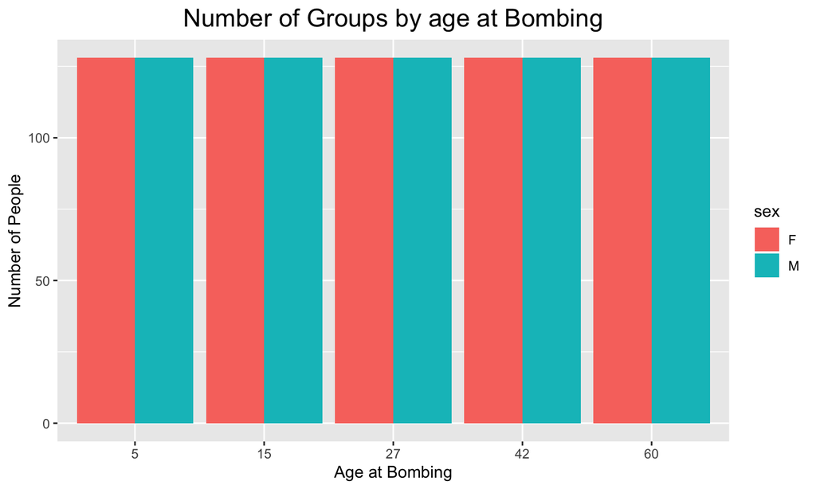

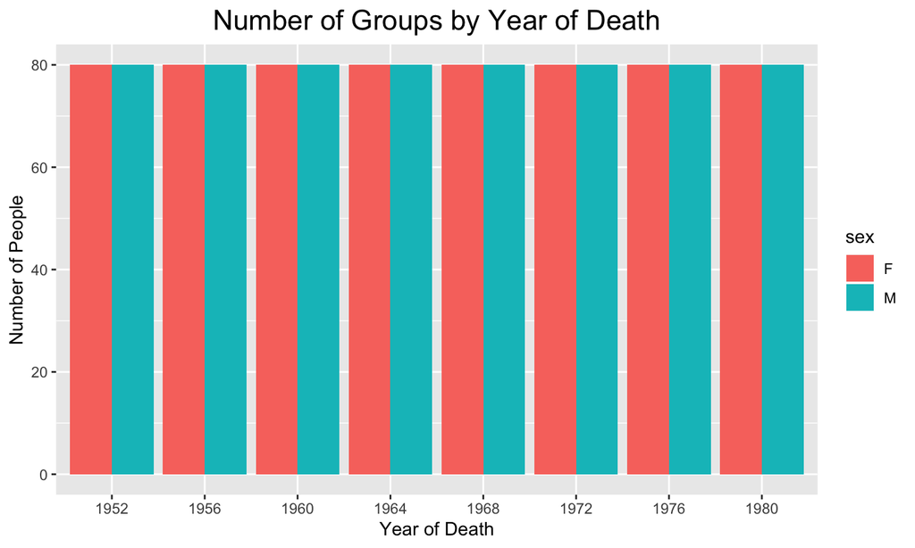

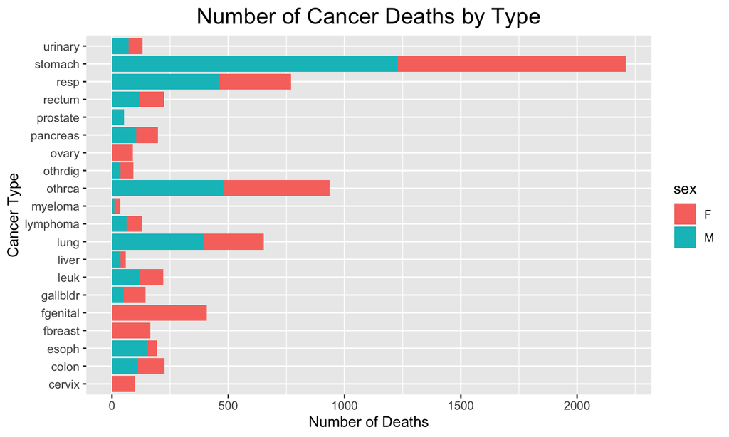

This graph summarizes the number of deaths for each cancer type. Most notably, and stomach cancers were the most prevalent.

https://www.ncbi.nlm.nih.gov/pmc/articles/PMC1860129/

Japanese people more susceptible to gastritis (inflammation of protective lining of the stomach), and therefore more susceptible to stomach cancers.

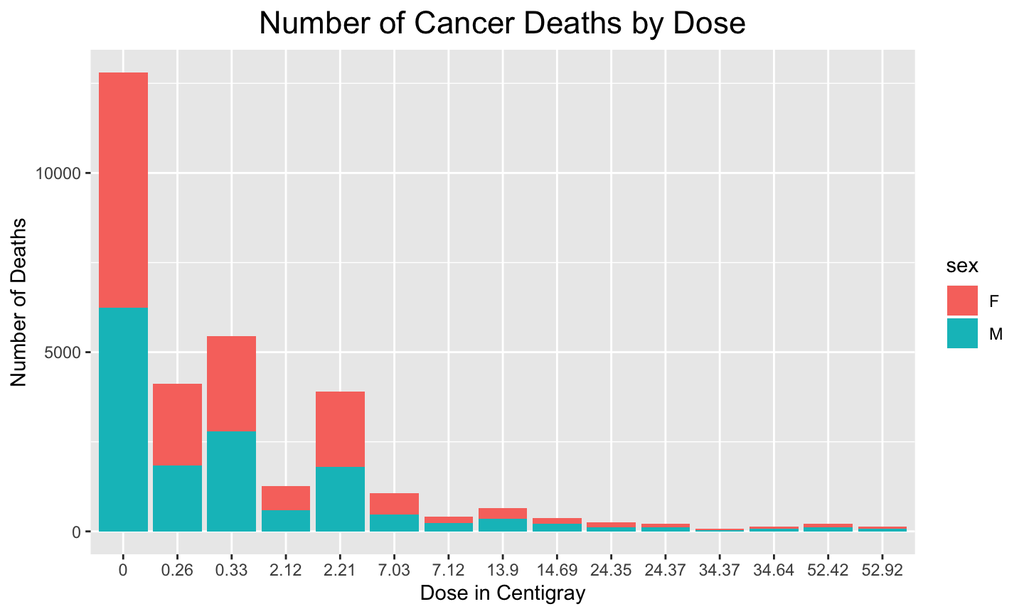

Many more people died of cancer at extremely low doses (most people had an exposure of less than .1 centigray). This is most likely because people who had much higher doses had died of the atomic bomb.

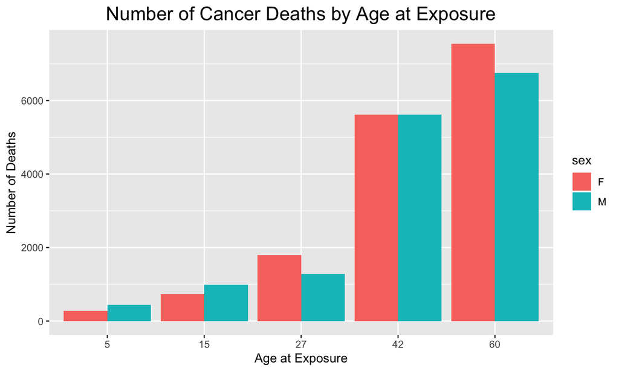

There were more deaths in people who were older at the time of the bombing.

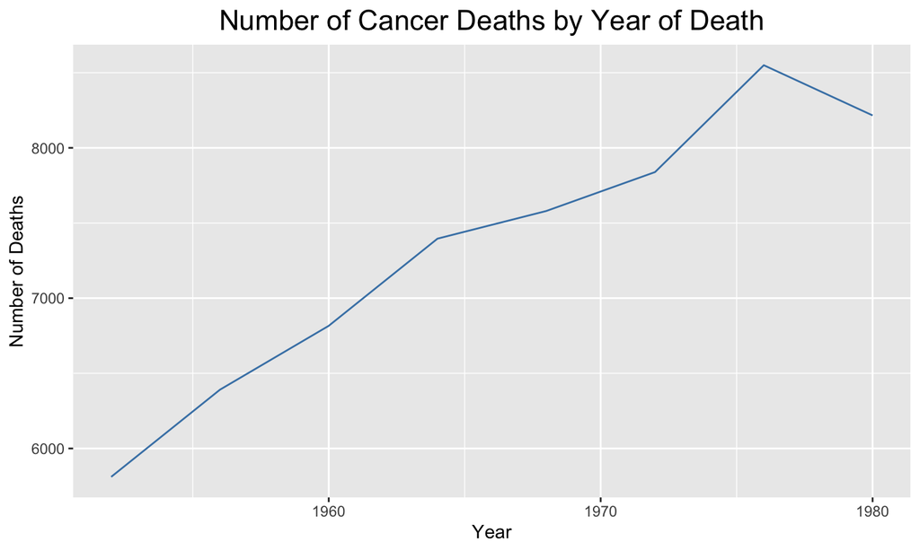

There is a positive trend in the people who died over the years. After 1976, there was a drop in the number of deaths.

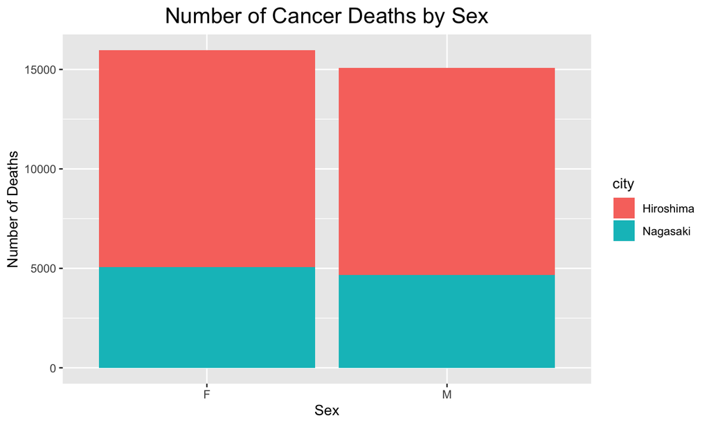

Females had more cancer deaths than males in total, and we are unsure of the reasons why.

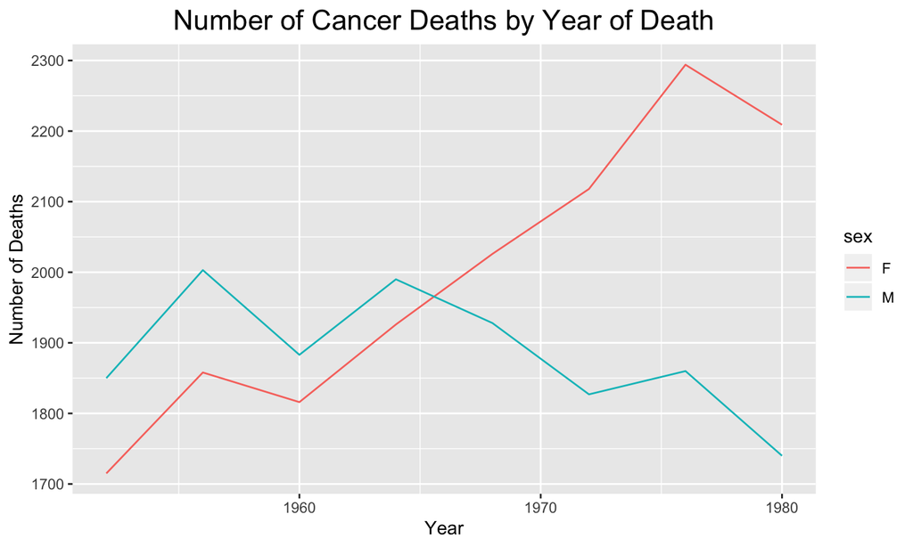

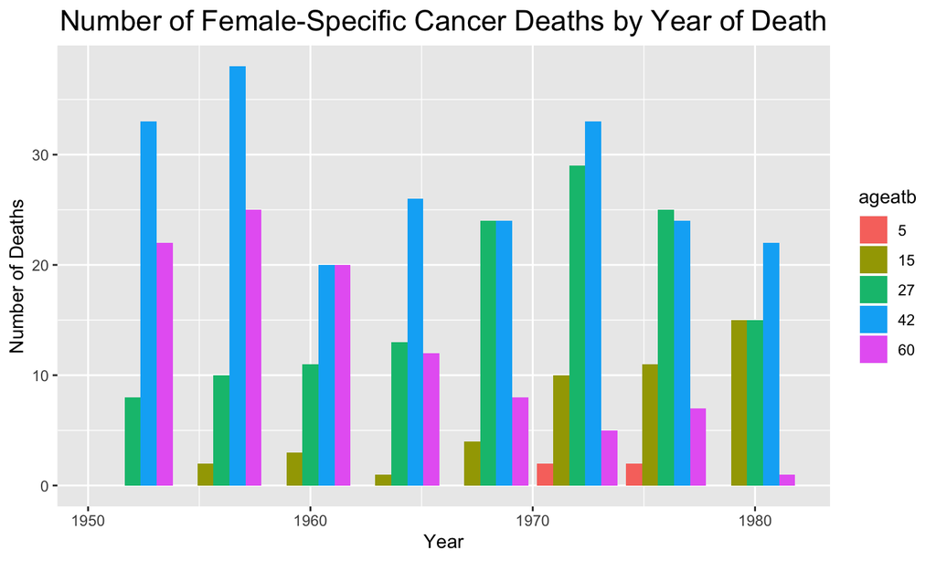

There is a downward trend in the number of deaths among 60 year olds and an upward trend among 27 year olds and 15 year olds at the time of the bombing.

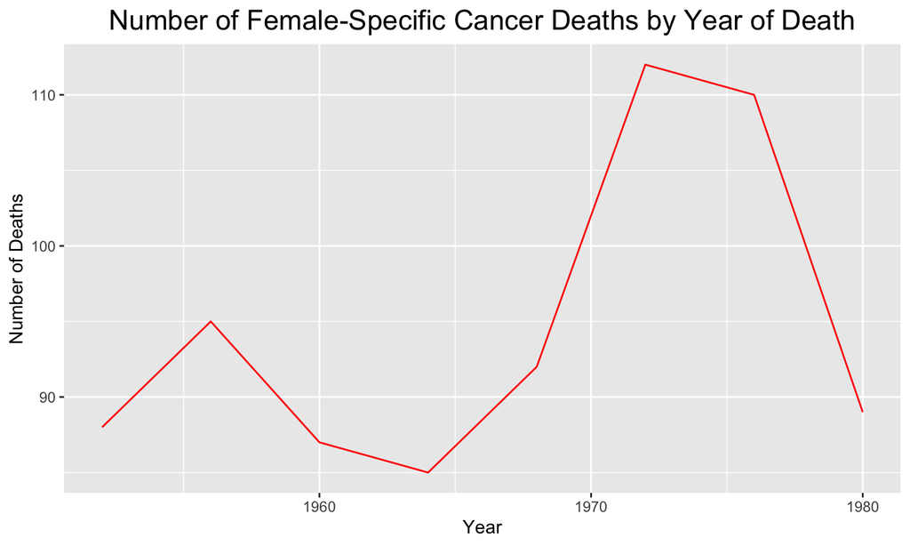

Between 1960 and 1970, there was a dip in female-specific cancer deaths (although we are not sure of why)

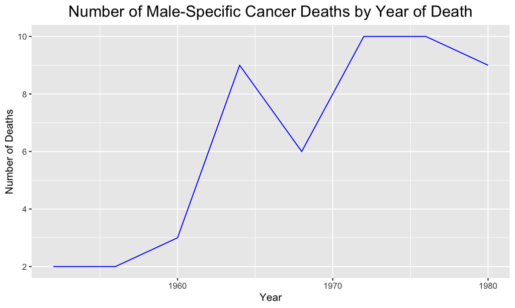

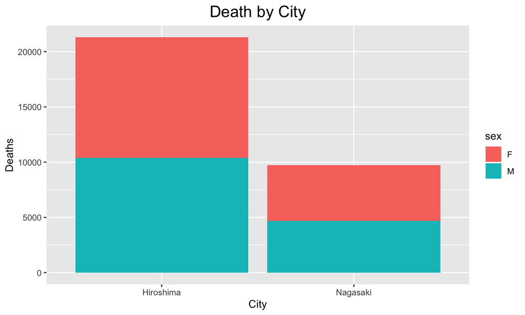

There were many more deaths in hiroshima than nagasaki, and this is because the population of Hiroshima was much bigger. Hiroshima = 350,000, Nagasaki = 263,000

https://www.cancer.gov/about-cancer/understanding/statistics